# Power Analysis for replication

Kevin Potter

May 3, 2016

## Introduction

This is a record of a power analysis for a third replication attempt on the Wimber et al. (2015) study on cortical suppression as an explanation of retrieval induced forgetting.

## Load in useful packages and data

```r
# Clear workspace
rm(list = ls())

# Define some useful functions
source('F0_Useful_functions.R')

# Package for fitting generalized linear models with mixed effects
# install.packages( 'lme4' )
library( lme4 )

# Package for C++ to R interface (Needs RTools or equivalent)
# install.packages( 'Rcpp' )
library( Rcpp )

# Load in original data
load( 'Data/Original_all_data.RData' )
```

## Define dependent and independent variables

## Estimates from original study

First, we’ll fit the original data kindly provided by Maria Wimber.

```r
str( dtbf ) # Structure of data to be fitted
```

```
## 'data.frame':    3293 obs. of  13 variables:
##  $ S    : num  1 1 1 1 1 1 1 1 1 1 ...
##  $ IN   : num  70 144 50 89 32 23 102 149 150 57 ...
##  $ Ac   : num  1 1 1 1 0 1 1 1 1 1 ...
##  $ Int  : num  1 1 1 1 1 1 1 1 1 1 ...
##  $ ITef : num  -1 -1 -1 -1 -1 -1 -1 -1 -1 -1 ...
##  $ SRef : num  1 -1 1 1 1 1 -1 1 1 1 ...
##  $ ITxSR: num  -1 1 -1 -1 -1 -1 1 -1 -1 -1 ...
##  $ TSR  : num  0 0 0 0 0 0 0 0 0 0 ...
##  $ TB   : num  0 0 0 0 0 0 0 0 0 0 ...
##  $ CSR  : num  1 0 1 1 1 1 0 1 1 1 ...
##  $ CB   : num  0 1 0 0 0 0 1 0 0 0 ...
##  $ Cnd  : num  4 1 4 4 4 4 1 4 4 4 ...
##  $ MR   : num  0 0 0 0 0 0 0 0 0 0 ...
```

```r
# S is an index for subjects
# IN is an index for items
# Ac is the accuracy ( 0 = wrong, 1 = right )
# Int is an intercept
# ITef is an effects coded variable ( -1 = baseline, +1 = selective retrieval )
# SRef is an effects coded variable ( -1 = Targets, +1 = Competitors )
# ITxSR is the interaction for the two above variables
# TSR is a dummy coded variable for the targets in the selective retrieval phase
# TB is a dummy coded variable for the targets in the baseline phase
# CSR is a dummy coded variable for the competitors in the selective retrieval phase
# CB is a dummy coded variable for the competitors in the baseline phase
# Cnd is a variable numerically coding the unique combination of condition levels
# MR is an indicator for missing responses
```

We’ll use a generalized linear model in which the data follows a bernoulli distribution, and we’ll include random effects for subjects and items. We’ll fit a model that posits there is no effect for baseline conditions and for target images that underwent selective retrieval, but there is an effect for competitor images that underwent selective retrieval:

```r
RIF_model = glmer( Ac ~ 1 + CSR + (1|S) + (1|IN), data = dtbf,
                 family = binomial(link='logit') )
```

Examining the coefficients, the RIF model suggests that there is a drop of about 4% in the performance in recognition memory predicted in the population.

```r
RIF_results = summary( RIF_model )
print( round( RIF_results$coefficients[2,], 3 ) )
```

```
##   Estimate Std. Error    z value   Pr(>|z|)
##     -0.290      0.094     -3.089      0.002
```

```r
# Convert to percentage
Intercept = RIF_results$coefficients[1,1]
RIF = RIF_results$coefficients[2,1]
print( round( 100*( logistic( Intercept ) -
                      logistic( Intercept + RIF ) ) ) )
```

```
## [1] 4
```

## Power curves

We’ll use that as our upper bound for the power analyses, since effect sizes are typically over-estimated due to how the literature only publishes significant findings. We’ll test results for 0% to 4% in approximately 1% increments.

```r
# Loop through some possible combinations
RIF_effect = seq( -.29, 0, length = 5 )
```

Next, we’ll define a general purpose function to simulate observations from a logistic regression model with subject and item effects in C++ (for speed):

```r
cpp_code = '
NumericVector genLinModSim( Rcpp::List input ) {
  /*
  Purpose:
  A function to simulate a hierarchical logistic regression
  model with random intercepts for subjects and items.
  Arguments:
  input - A list consisting of...
          X         = A design matrix for the fixed effects
          beta      = A column vector with the generating parameters
                      for the fixed effects
          Ns        = The number of subjects
          subjIndex = An index indicating which observations belong
                      to which subjects
          sigma_s   = The standard deviation for the subject random
                      intercepts
          Ni        = The number of items
          itemIndex = An index indicating which observations belong
                      to which items
          sigma_i   = The standard deviation for the item random
                      intercepts
  Returns:
  A vector of binary responses.
  */

  // Extract design matrix
  arma::mat X = input[ "X" ];

  // Number of observations to simulate
  int Nt = X.n_rows;

  // Extract generating parameters

  // Fixed effects
  arma::mat beta = input[ "beta" ];
  arma::mat mu = X * beta;

  // Initialize variable for indexing random effects
  int ind;

  // Random intercept for subjects
  int Ns = input[ "Ns" ];
  if ( Ns > 0 ) {

    // Extract index for subjects
    IntegerVector subjIndex = input[ "subjIndex" ];

    // Generate random intercept for every subject
    double sigma_s = input[ "sigma_s" ];
    NumericVector eta = rnorm( Ns, 0.0, sigma_s );

    for ( int i = 0; i < Nt; i++ ) {
      ind = subjIndex( i ) - 1;
      if ( ind > -1 ) mu( i, 0 ) = mu( i, 0 ) + eta( ind );
    }
  }

  // Random intercept for items
  int Ni = input[ "Ni" ];
  if ( Ni > 0 ) {

    // Extract index for items
    IntegerVector itemIndex = input[ "itemIndex" ];

    // Generate random intercept for every item
    double sigma_i = input[ "sigma_i" ];
    NumericVector zeta = rnorm( Ni, 0.0, sigma_i );

    for ( int i = 0; i < Nt; i++ ) {
      ind = itemIndex( i ) - 1;
      if ( ind > -1 ) mu( i, 0 ) = mu( i, 0 ) + zeta( ind );
    }
  }

  // Initialize output
  NumericVector out( Nt );
  for ( int i = 0; i < Nt; i++ ) {
    out( i ) = R::rbinom( 1, 1.0/( 1.0 + exp( -mu( i ) ) ) );
  }

  return( out );
}
'

cppFunction( cpp_code, depends = 'RcppArmadillo' )

# Clean up workspace
rm( cpp_code )
```

We will also specify the variables needed to represent the experimental design:

```r
# Sample size
Ns = c( 24, 48 )

# Number of trials per condition
Nt = c(
  18, # Baseline (Competitors)
  18, # Baseline (Targets)
  54, # Selective retrieval (Targets)
  54  # Selective retrieval (Competitors)
)

# Number of items
Ni = sum( Nt )

# Experimental conditions
Associate = c(
  rep(  0, Nt[1] ),
  rep(  1, Nt[2] ),
  rep(  1, Nt[3] ),
  rep(  0, Nt[4] )
)
# (0 = competitor, 1 = target)

Retrieval = c(
  rep(  0, Nt[1] ),
  rep(  0, Nt[2] ),
  rep(  1, Nt[3] ),
  rep(  1, Nt[4] )
)
# (0 = baseline, 1 = selective retrieval)

# Dummy coded variable for simple effect of forgetting for competitors
SEF = c(
  rep(  0, Nt[1] ),
  rep(  0, Nt[2] ),
  rep(  0, Nt[3] ),
  rep(  1, Nt[4] )
)
```

The generating parameters for the intercept and standard deviations of the random intercepts will be based on the estimates from the original data:

```r
# Extract intercept
Int = fixef( RIF_model )[1]

# Extract standard deviations for subject and item effects
sigma_i = as.numeric( attributes( VarCorr( RIF_model )$IN )$stddev )
sigma_s = as.numeric( attributes( VarCorr( RIF_model )$S )$stddev )
```

We’ll run 1,000 iterations, which results in about +/- 2% accuracy in the estimates.

```r
# Define number of iterations
nRep = 1000
```

We’ll loop over all sample sizes and effect sizes. Note that the computations are very slow (it takes about 5 hours to run the following code):

```r
# Initialize matrices to store results
p_value_power_analysis = matrix( NA, length( Ns ),
                                 length( RIF_effect ) )
MC_error = array( NA, dim = c( 2, length( Ns ),
                               length( RIF_effect ) ) )

# Define function to randomize item position
f = function() {
  return( sample( 1:( sum(Nt) ) ) )
}

# Define function to estimate Monte carlo error via
# a resampling method
f2 = function(i) {
  ind = 1:(dim( output )[2])
  return( sum( output[5,sample(ind,replace=T),i] < .05 ) )
}

# Loop over sample sizes
for ( s in 1:length( Ns ) ) {

  print( paste( 'Sample size:', Ns[s] ) )

  # Initialize variables
  CSR = rep( SEF, Ns[s] ) # Simple effect for forgetting
  IT = rep( Associate, Ns[s] )
  SR = rep( Retrieval, Ns[s] )
  # Index for subjects
  S = rep( 1:Ns[s], each = sum(Nt) )
  # Index for items
  IN = as.vector( replicate( Ns[s], f() ) )
  # Design matrix for fixed effects
  X = cbind( 1, CSR )

  # Initialize array for output
  output = array( NA, dim = c( ncol( X ) + 3, nRep,
                               length( RIF_effect ) ) )

  # Loop over effect sizes
  for ( e in 1:length( RIF_effect ) ) {

    print( paste( 'Effect size:', e ) )

    # Define input for simulation function
    input = list(
      X = X,
      Ns = Ns[s],
      Ni = Ni,
      subjIndex = S,
      itemIndex = IN,
      beta = rbind( Int, RIF_effect[e] ),
      sigma_s = sigma_s,
      sigma_i = sigma_i
    )

    # Loop over iterations
    for ( nr in 1:nRep ) {

      if ( nr == 1 ) startTime = Sys.time()

      # Simulate data
      sim = genLinModSim( input )

      # Parameter recovery
      fit = glmer( sim ~ 1 + CSR + # Fixed effects
                     (1|S) + (1|IN), # Random effects
                   family = binomial('logit') )
      fe = fixef( fit )
      std = c(
        as.numeric( attributes( VarCorr( fit )$IN )$stddev ),
        as.numeric( attributes( VarCorr( fit )$S )$stddev )
      )

      output[1,nr,e] = fe[1]
      output[2,nr,e] = fe[2]
      output[3,nr,e] = std[1]
      output[4,nr,e] = std[2]
      output[5,nr,e] = summary( fit )$coefficients[2,4]

      if ( nr == 1 ) {
        runTime = Sys.time() - startTime
        print( paste( 'Estimated run time:',
                      round( (runTime * nRep)/60, 2 ),
                      'minutes' ) )
        # Clean up workspace
        rm( startTime, runTime )
      }

      # Clean up workspace
      rm( sim, fit, fe, std )
    }

    # Estimate MC error
    MC_error[,s,e] = quick_ui( replicate( 10000, f2(e) )/nRep )
  }

  # Monte carlo approximations for power
  p_value_power_analysis[s,] = colSums( output[5,,] < .05 )/nRep

  # Clean up workspace
  rm( output, grp_mns )
}

# Save the results for easy access
save( p_value_power_analysis,
      ppc_power_analysis,
      MC_error, file = 'Data/power_analysis_1000.RData' )
```

Simulating data using the RIF model and refitting the model to the simulations generates the following power-curves for sample sizes of 24 (the original study) and 48 (the proposed replication):

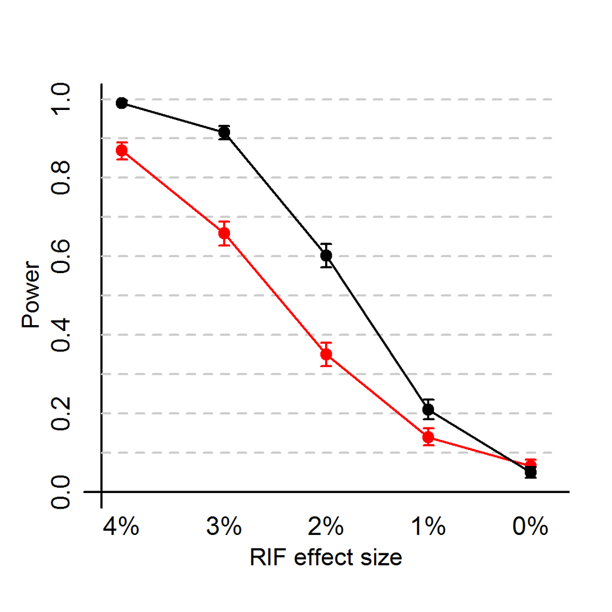

Error bars represent 95% confidence intervals determined via the resampling function. We can display a table of the precise amounts:

```r
p_value_power_analysis =
  as.data.frame( p_value_power_analysis )
print( p_value_power_analysis )
```

```
##        4%    3%    2%   1%    0%
## N24 0.869 0.658 0.350 0.14 0.066
## N48 0.990 0.915 0.602 0.21 0.050
```

As can be seen, with 48 subjects, we have an estimated power over 95% to detect an effect size of only 4% and we still have 90% power to detect an effect of 3% (the authors report an effect size of 7% in their paper).

## Posterior predictive checks

We also plan to conduct a posterior predictive check, examining whether the condition means for average performance from our replication fall within the 95% credible intervals from the original study.

The 95% credible intervals will be based on Wimber et al.’s original data with missing responses recoded as errors:

```r
# Isolate variables of interest
dtbf = fr[, c('S','IN','Ac','Int','ITef','SRef','ITxSR',
              'TSR','TB','CSR','CB','Cnd','MR') ]

# Set missing values to errors
dtbf$Ac[ dtbf$MR == 1 ] = 0

# Fit hierarchical logistic regression
RIF_model = glmer( Ac ~ 1 + CSR + (1|S) + (1|IN), data = dtbf,
                 family = binomial(link='logit') )

# Extract intercept
Int = fixef( RIF_model )[1]

# Extract standard deviations for subject and item effects
sigma_i = as.numeric( attributes( VarCorr( RIF_model )$IN )$stddev )
sigma_s = as.numeric( attributes( VarCorr( RIF_model )$S )$stddev )
```

Fitting the same hierarchical logistic regression model with mildly informative priors (a N(1.775, 0.3) on the intercept, and a N(-0.3, 0.3) on the coefficient for the simple effect of forgetting), we get the following posterior predictive intervals for each condition:

```r
post_pred_check = rbind(
  LB = c( TB = 0.7569, CB = 0.7569, TSR = 0.7701, CSR = 0.7199 ),
  UB = c( TB = 0.8356, CB = 0.8356, TSR = 0.8225, CSR = 0.7824 )
)
```

We can simulate the model under different RIF effects and examine how often the observed data will fall outside the interval:

```r
# Matrix for output
ppc_power_analysis = matrix( NA, 4, length( RIF_effect ) )
# Matrix for MC error
MC_error = array( NA, dim = c( 4, length( RIF_effect ), 2 ) )

# Define function to randomize item position
f = function() {
  return( sample( 1:( sum(Nt) ) ) )
}

# Define function to estimate Monte carlo error via
# a resampling method
f2 = function(i,e) {
  ind = 1:(dim( grp_mns )[2])
  out = sum( grp_mns[i,sample(ind,replace=T),e] >
            post_pred_check[1,i] &
        grp_mns[i,sample(ind,replace=T),e] <
            post_pred_check[2,i] )/nRep
  return( out )
}

# Number of iterations to run
nRep = 1000

# Initialize array for group means
grp_mns = array( NA, dim = c( 4, nRep,
                              length( RIF_effect ) ) )

# Initialize variables
CSR = rep( SEF, Ns[s] ) # Simple effect for forgetting
IT = rep( Associate, Ns[2] )
SR = rep( Retrieval, Ns[2] )
# Index for subjects
S = rep( 1:Ns[2], each = sum(Nt) )
# Index for items
IN = as.vector( replicate( Ns[2], f() ) )
# Design matrix for fixed effects
X = cbind( 1, CSR )

# Loop over different effect sizes
for ( e in 1:length( RIF_effect ) ) {

  print( paste( 'Effect size:', e ) )

  # Define input for simulation function
  input = list(
    X = X,
    Ns = Ns[2],
    Ni = Ni,
    subjIndex = S,
    itemIndex = IN,
    beta = rbind( Int, RIF_effect[e] ),
    sigma_s = sigma_s,
    sigma_i = sigma_i
  )

  for ( nr in 1:nRep ) {

    if ( nr == 1 ) startTime = Sys.time()

    # Simulate data
    sim = genLinModSim( input )

    grp_mns[1,nr,e] = mean( sim[ IT == 1 & SR == 0 ] )
    grp_mns[2,nr,e] = mean( sim[ IT == 0 & SR == 0 ] )
    grp_mns[3,nr,e] = mean( sim[ IT == 1 & SR == 1 ] )
    grp_mns[4,nr,e] = mean( sim[ IT == 0 & SR == 1 ] )

    if ( nr == 1 ) {
      runTime = Sys.time() - startTime
      print( paste( 'Estimated run time:',
                    round( (runTime * nRep)/60, 2 ),
                    'minutes' ) )
      # Clean up workspace
      rm( startTime, runTime )
    }

  }

  # Power based on posterior predictive check
  for ( i in 1:4 ) {
    ppc_power_analysis[i,e] =
      sum( grp_mns[i,,e] > post_pred_check[1,i] &
        grp_mns[i,,e] < post_pred_check[2,i] )/nRep
    MC_error[i,e,] = quick_ui( replicate( 10000, f2(i,e) ) )
  }

}
```

```
## [1] "Effect size: 1"
## [1] "Estimated run time: 0.03 minutes"
## [1] "Effect size: 2"
## [1] "Estimated run time: 0.02 minutes"
## [1] "Effect size: 3"
## [1] "Estimated run time: 0.03 minutes"
## [1] "Effect size: 4"
## [1] "Estimated run time: 0.02 minutes"
## [1] "Effect size: 5"
## [1] "Estimated run time: 0.03 minutes"
```

```r
rownames( ppc_power_analysis ) =
  colnames( post_pred_check )
colnames( ppc_power_analysis ) =
  c( '4%', '3%', '2%', '1%', '0%' )
```

Below is a plot of the proportion of times out of a 1,000 iterations that the replication data with 48 subjects would fall within the 95% credible intervals of the original data under different RIF effect sizes:

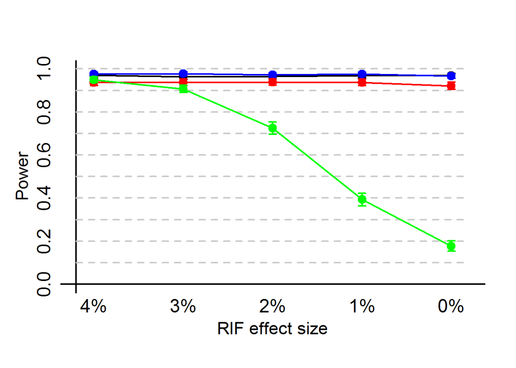

We can also display the estimated proportions:

```r
ppc_power_analysis =
  as.data.frame( ppc_power_analysis )
print( ppc_power_analysis )
```

```
##        4%    3%    2%    1%    0%
## TB  0.971 0.963 0.966 0.969 0.968
## CB  0.976 0.977 0.972 0.976 0.967
## TSR 0.937 0.937 0.938 0.937 0.921
## CSR 0.949 0.907 0.725 0.393 0.177
```